# Succession and Flowering Time

## Alpha Diversity

Calculate, statistical tests, and graphing of alpha diversity metrics

```r
#Prep data and create a dataframe to run statistics on
mic.assmblg <- data_rarefied
results <- estimate_richness(mic.assmblg, measures = c('Shannon', 'Simpson', 'Observed'))
d <- sample_data(mic.assmblg)
```

Alpha diversity by time point

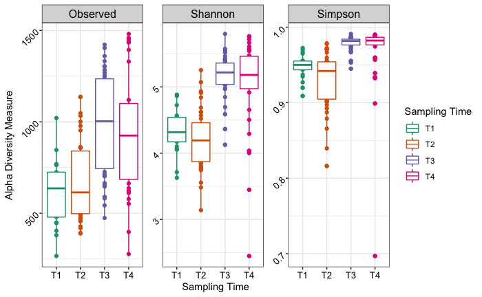

```r
timept
ggsave("/Users/gordoncuster/Desktop/Manuscript Submissions/Published/SuccessionFloweringTime/SuccessionFloweringTime/May_Updated_Meta_data/Final_Figures/Figure3A.tiff", device = "tiff")
```

Alpha diversity by phenotype (wild-type, early or late flowering)

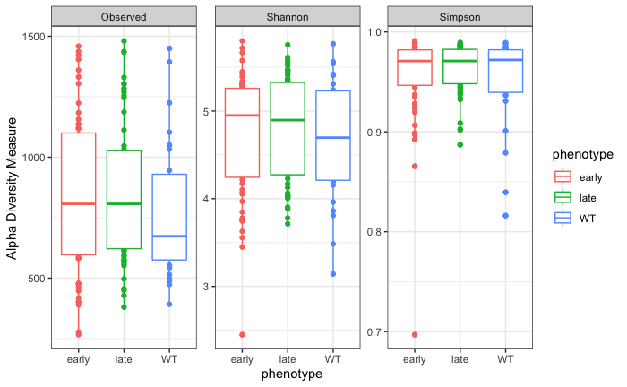

```r
#by flowering time
ft <- plot_richness(mic.assmblg, x = "phenotype", measures=c("Shannon","Simpson", "Observed"), color='phenotype')
ft <- ft + geom_boxplot() + theme_bw()
ft
```

```r
#Statistical testing of alpha diversity by phenotypes
tp_shannon<-kruskal.test(results$Shannon~ factor(d$phenotype))
dunnTest(results$Shannon~ factor(d$phenotype), method = "bon")
```

```
Dunn (1964) Kruskal-Wallis multiple comparison
  p-values adjusted with the Bonferroni method.
```

| Comparison | Z | P.unadj | P.adj |
| --- | --- | --- | --- |
| early - late | -0.4833675 | 0.6288348 | 1 |
| early - WT | 0.2142889 | 0.8303218 | 1 |
| late - WT | 0.6041728 | 0.5457288 | 1 |

```r
tp_simpson<-kruskal.test(results$Simpson~ factor(d$phenotype))
dunnTest(results$Simpson~ factor(d$phenotype), method = "bon")
```

```
Dunn (1964) Kruskal-Wallis multiple comparison
  p-values adjusted with the Bonferroni method.
```

| Comparison | Z | P.unadj | P.adj |
| --- | --- | --- | --- |
| early - late | -0.3167699 | 0.7514182 | 1 |
| early - WT | 0.3740418 | 0.7083733 | 1 |
| late - WT | 0.6295482 | 0.5289902 | 1 |

```r
tp_observed<-kruskal.test(results$Observed~ factor(d$phenotype))
dunnTest(results$Observed~ factor(d$phenotype), method = "bon")
```

```
Dunn (1964) Kruskal-Wallis multiple comparison
  p-values adjusted with the Bonferroni method.
```

| Comparison | Z | P.unadj | P.adj |
| --- | --- | --- | --- |
| early - late | -0.6089077 | 0.5425856 | 1.000000 |
| early - WT | 0.7945654 | 0.4268663 | 1.000000 |
| late - WT | 1.2857099 | 0.1985443 | 0.595633 |

Alpha diversity by plant genotypes at time point 1. This allows us to say that they were similar at the beginning, so differences were likely due to flowering time or time since germination.

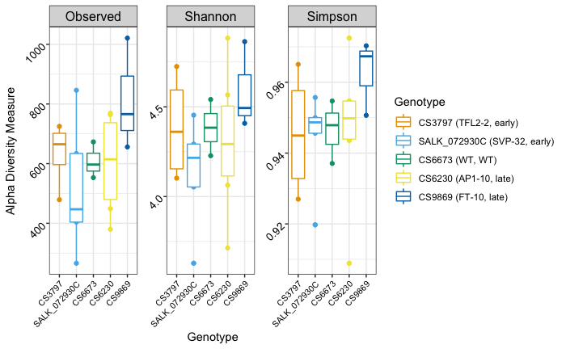

Alpha diversity of developmental stage

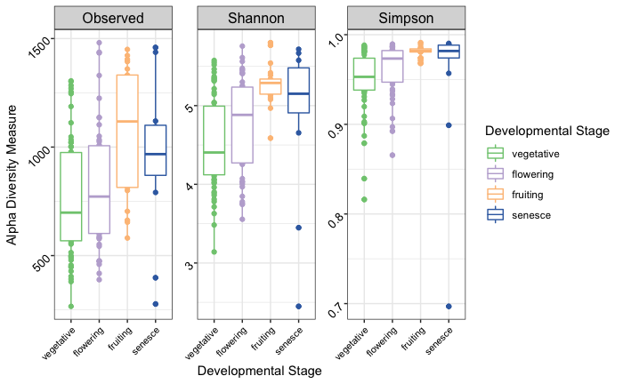

```r
status
ggsave("/Users/gordoncuster/Desktop/Manuscript Submissions/Published/SuccessionFloweringTime/SuccessionFloweringTime/May_Updated_Meta_data/Final_Figures/Figure4A.tiff", device = "tiff")
```

## Multivariate analyses - Beta-diversity

Prepare data frame for multivariate analyses

```r
#extract relevant data: OTU table and Metadata
taxa_table<-data.frame(otu_table(data_transformed))
samp_data <- data.frame(sample_data(data_transformed))
#ordinate
psdist<-parDist(as.matrix(taxa_table), method = "bray")
ord<-metaMDS(taxa_table, distance = "bray", k=3, trymax = 100, previous.best = T)
```

```
*** Solution reached
```

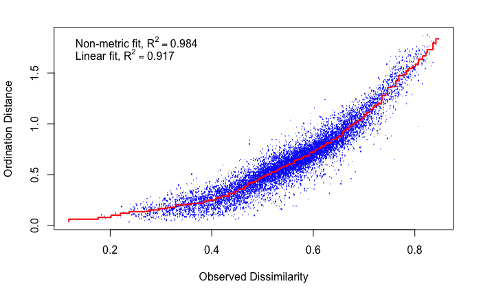

```r
stressplot(ord)
```

Adonis testing and ordination by Time point

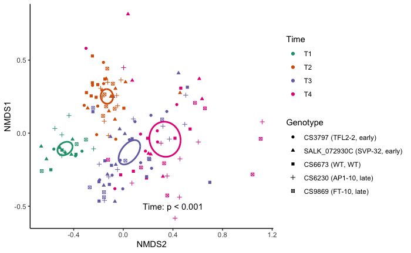

```r
t
ggsave("/Users/gordoncuster/Desktop/Manuscript Submissions/Published/SuccessionFloweringTime/SuccessionFloweringTime/May_Updated_Meta_data/Final_Figures/Figure3B.tiff", device = "tiff")
```

This can be used to subset to individual time points.

```r
ggsave("/Users/gordoncuster/Desktop/Manuscript Submissions/Published/SuccessionFloweringTime/SuccessionFloweringTime/May_Updated_Meta_data/Final_Figures/Figure2B.tiff", device = "tiff")
```

Phenotype

```r
adonis(psdist ~  phenotype, data = data.frame((samp_data)), permutations = 100)
#not significant so no need to do pairwise comparisons.

#make the plot with everything on it and we can subset from there.
d <- gg_ordiplot(ord, samp_data$phenotype, choices = c(1, 2), kind = c("se"), conf = 0.95, show.groups = "all", ellipse = TRUE, label = FALSE, hull = FALSE, spiders = FALSE, plot = TRUE, pt.size = 1)
#pull out the ellipses
df_ellipse <- d$df_ellipse
ellipsep1 <- subset(df_ellipse, Group == "early", droplevels= TRUE)
ellipsep2 <- subset(df_ellipse, Group == "late", droplevels= TRUE)
ellipsep3 <- subset(df_ellipse, Group == "WT", droplevels= TRUE)

#make the dataframe and and rename for manual plotting with ggplot
test<-d$df_ord
test$Sample_ID<-rownames(test)
dat<-data.frame(samp_data$Sampling_time, samp_data$phenotype, samp_data$Genotype, rownames(samp_data))
names(dat)<-c("Time", "Phenotype", "Genotype", "Sample_ID")
test<-full_join(test, dat)
names(test)<-c("x", "y","phenotype2","SampleID", "Time", "Phenotype", "Genotype")

#make the ggplot scatter plot
plot_test<-ggplot(test, aes(x=test$x, y=test$y), color=Phenotype) + scale_color_manual(values=c("#F564E3", "#619CFF", "#F8766D", "#009E73", "#000000")) + geom_point(aes(color=Phenotype, shape = Genotype))
#add paths, color, and size, of the hulls
plot_test <- plot_test +
  geom_path(data= ellipsep1, aes(x=x, y=y), color="#F564E3", linetype="solid", size=1.0) +
    geom_path(data= ellipsep2, aes(x=x, y=y), color="#619CFF", linetype="solid", size=1.0) +
    geom_path(data= ellipsep3, aes(x=x, y=y), color="#F8766D", linetype="solid", size=1.0)

plot_test<- plot_test + theme_classic()
m<-plot_test
m <-m + annotate("text", x = 0.4, y = -0.5, label = "Time: P  = 0.27")
m<- m + labs(x= "NMDS2", y="NMDS1")
p <- m + ggtitle("Ordination by Phenotype") + theme(plot.title = element_text(hjust = 0.5, size = 22))
p
```

Flowering Status

```r
adonis(psdist ~  Sampling_time, data= data.frame((samp_data)), permutations = 1000)
pairwise<-pairwise.adonis2(taxa_table ~ Developmental_stage, data = data.frame(samp_data), perm=1000, p.adjust.methods="bonferroni")
summary(pairwise)
pairwise

#make the plot with everything and go from there
d <- gg_ordiplot(ord, samp_data$Developmental_stage, choices = c(1, 2), kind = c("se"), conf = 0.95, show.groups = "all", ellipse = TRUE, label = FALSE, hull = FALSE, spiders = FALSE, plot = TRUE, pt.size = 1)
#pull out the ellipses
df_ellipse <- d$df_ellipse
ellipses1 <- subset(df_ellipse, Group == "senesce", droplevels= TRUE)
ellipses2 <- subset(df_ellipse, Group == "flowering", droplevels= TRUE)
ellipses3 <- subset(df_ellipse, Group == "fruiting", droplevels= TRUE)
ellipses5 <- subset(df_ellipse, Group == "vegetative", droplevels= TRUE)

#make the dataframe and and rename for manual plotting with ggplot
test<-d$df_ord
test$Sample_ID<-rownames(test)
dat<-data.frame(samp_data$Sampling_time, samp_data$phenotype, samp_data$Genotype, rownames(samp_data))
names(dat)<-c("Time", "Phenotype", "Genotype", "Sample_ID")
test<-full_join(test, dat)
#test$Group=NULL
names(test)<-c("x", "y","Developmental Stage","SampleID", "Time", "Phenotype", "Genotype")
test$`Developmental Stage` <- factor(test$`Developmental Stage`, levels = c("vegetative",  "flowering", "fruiting","senesce"))
#make the ggplot scatter plot
#plot_test<-ggplot(test, aes(x=test$x, y=test$y), color=Developmental_stage) + scale_color_manual(values=c("#F564E3", "#619CFF", "#FDC086", "#386CB0")) + geom_point(aes(color= Developmental_stage, shape=Time))
plot_test<-ggplot(test, aes(x=test$x, y=test$y), color=`Developmental Stage`) + scale_color_manual(values=c("#7FC97F", "#BEAED4", "#F8766D","#386CB0" )) + geom_point(aes(color= `Developmental Stage`, shape=Time))
#add paths, color, and size, of the hulls
plot_test <- plot_test +
  geom_path(data= ellipses1, aes(x=x, y=y), color="#7FC97F", linetype="solid", size=1.0) +
    geom_path(data= ellipses2, aes(x=x, y=y), color="#BEAED4", linetype="solid", size=1.0) +
    geom_path(data= ellipses3, aes(x=x, y=y), color="#FDC086", linetype="solid", size=1.0) +
    geom_path(data= ellipses5, aes(x=x, y=y), color="#386CB0", linetype="solid", size=1.0)

plot_test<- plot_test + theme_classic()
m<-plot_test
m <-m + annotate("text", x = 0.4, y = -0.5, label = "Developmental Stage: p < 0.01")
m<- m + labs(x= "NMDS2", y="NMDS1")
s <- m
s
```

```r
grid.arrange(t, s, p, g)
```

## Strata argument for nesting of analyses

testing with nesting by developmental stage or by sampling time

```r
adonis(psdist ~ Sampling_time, data= data.frame((samp_data)), strata = samp_data$Developmental_stage, permutations = 1000)
adonis(psdist ~ Sampling_time, data= data.frame((samp_data)), permutations = 1000)

adonis(psdist ~ Developmental_stage, data= data.frame((samp_data)), strata = samp_data$Sampling_time, permutations = 1000)
adonis(psdist ~ Developmental_stage, data= data.frame((samp_data)), permutations = 1000)
```

# Split by time point and examine flowering status at each time point.

```r
time1<- subset_samples(data_rarefied, Sampling_time == "T1")
time2<- subset_samples(data_rarefied, Sampling_time == "T2")
time3<- subset_samples(data_rarefied, Sampling_time == "T3")
time4<- subset_samples(data_rarefied, Sampling_time == "T4")

time1_t<- subset_samples(data_transformed, Sampling_time == "T1")
time2_t<- subset_samples(data_transformed, Sampling_time == "T2")
time3_t<- subset_samples(data_transformed, Sampling_time == "T3")
time4_t<- subset_samples(data_transformed, Sampling_time == "T4")
```

Diversity (alpha and beta) split by time point and examining impact of Developmental stage Time 1

```r
mic.assmblg <- time1
results <- estimate_richness(time1, measures = c('Shannon', 'Simpson', 'Observed'))
d <- sample_data(time1)

#sample_data(time1)$status <-  factor(sample_data(time1)$status, levels = c("veg", "preflwr"), ordered = T)

#by time point
time1_status_alpha <- plot_richness(time1, x = "Developmental_stage", measures=c("Shannon","Simpson", "Observed"), color='Developmental_stage') #, shape="time_point")
#Pheno <- Pheno + scale_colour_manual(values = c("#CD6821","#CD6821","#CD6821","#CD6821","#158172","#158172","#158172","#158172","#214788","#214788","#214788","#214788"))
time1_status_alpha <- time1_status_alpha + geom_boxplot() + theme_bw()
time1_status_alpha

#At time 1 All samples are in the same developmental stage so no need for statistical testing.
```

Time 2

```r
mic.assmblg <- time2
results <- estimate_richness(time2, measures = c('Shannon', 'Simpson', 'Observed'))
d <- sample_data(time2)

sample_data(time2)$Developmental_stage <-  factor(sample_data(time2)$Developmental_stage, levels = c("vegetative", "flowering"), ordered = T)


#by time point 2
time2_status_alpha <- plot_richness(time2, x = "Developmental_stage", measures=c("Shannon","Simpson", "Observed"), color='Developmental_stage') #, shape="time_point")
#Pheno <- Pheno + scale_colour_manual(values = c("#CD6821","#CD6821","#CD6821","#CD6821","#158172","#158172","#158172","#158172","#214788","#214788","#214788","#214788"))
time2_status_alpha <- time2_status_alpha + geom_boxplot() + theme_bw()
time2_status_alpha


t2_shannon<-kruskal.test(results$Shannon~ factor(d$Developmental_stage))
dunnTest(results$Shannon~ factor(d$Developmental_stage), method = "bon")

t2_simpson<-kruskal.test(results$Simpson~ factor(d$Developmental_stage))
dunnTest(results$Simpson~ factor(d$Developmental_stage), method = "bon")

t2_observed<-kruskal.test(results$Observed~ factor(d$Developmental_stage))
dunnTest(results$Observed~ factor(d$Developmental_stage), method = "bon")



taxa_table<-data.frame(otu_table(time2_t))
samp_data <- data.frame(sample_data(time2_t))
psdist<-parDist(as.matrix(taxa_table), method = "bray")
ord<-metaMDS(taxa_table, distance = "bray", k=3, trymax = 1000, previous.best = T)
stressplot(ord)

adonis(psdist ~  Developmental_stage , data = data.frame((samp_data)))
```

Time 3

```r
mic.assmblg <- time3
results <- estimate_richness(time3, measures = c('Shannon', 'Simpson', 'Observed'))
d <- sample_data(time3)

sample_data(time3)$Developmental_stage <-  factor(sample_data(time3)$Developmental_stage, levels = c("vegetative", "flowering", "fruiting"), ordered = T)

#by time point
time3_status_alpha <- plot_richness(time3, x = "Developmental_stage", measures=c("Shannon","Simpson", "Observed"), color='Developmental_stage') #, shape="time_point")
time3_status_alpha <- time3_status_alpha + geom_boxplot() + theme_bw()
time3_status_alpha

t3_shannon<-kruskal.test(results$Shannon~ factor(d$Developmental_stage))
dunnTest(results$Shannon~ factor(d$Developmental_stage), method = "bon")

t3_simpson<-kruskal.test(results$Simpson~ factor(d$Developmental_stage))
dunnTest(results$Simpson~ factor(d$Developmental_stage), method = "bon")

t3_observed<-kruskal.test(results$Observed~ factor(d$Developmental_stage))
dunnTest(results$Observed~ factor(d$Developmental_stage), method = "bon")


taxa_table<-data.frame(otu_table(time3_t))
samp_data <- sample_data(time3_t)
psdist<-parDist(as.matrix(taxa_table), method = "bray")
ord<-metaMDS(taxa_table, distance = "bray", k=3, trymax = 100, previous.best = T)
stressplot(ord)

adonis(psdist ~  Developmental_stage , data = data.frame((samp_data)))
```

Time 4

```r
mic.assmblg <- time4
results <- estimate_richness(time4, measures = c('Shannon', 'Simpson', 'Observed'))
d <- sample_data(time4)

sample_data(time4)$Developmental_stage <-  factor(sample_data(time4)$Developmental_stage, levels = c("vegetative", "flowering", "fruiting", "senesce"), ordered = T)

#by time point
time4_status_alpha <- plot_richness(time4, x = "Developmental_stage", measures=c("Shannon","Simpson", "Observed"), color='Developmental_stage') #, shape="time_point")
time4_status_alpha <- time4_status_alpha + geom_boxplot() + theme_bw()
time4_status_alpha

#shapiro.test(aov(results$Shannon~d$time_point)$residuals)
t4_shannon<-kruskal.test(results$Shannon~ factor(d$Developmental_stage))
dunnTest(results$Shannon~ factor(d$Developmental_stage), method = "bon")

t4_simpson<-kruskal.test(results$Simpson~ factor(d$Developmental_stage))
dunnTest(results$Simpson~ factor(d$Developmental_stage), method = "bon")

t4_observed<-kruskal.test(results$Observed~ factor(d$Developmental_stage))
dunnTest(results$Observed~ factor(d$Developmental_stage), method = "bon")


taxa_table<-data.frame(otu_table(time4_t))
samp_data <- sample_data(time4_t)
psdist<-parDist(as.matrix(taxa_table), method = "bray")
ord<-metaMDS(taxa_table, distance = "bray", k=3, trymax = 100, previous.best = T)
stressplot(ord)

adonis(psdist ~  Developmental_stage , data = data.frame((samp_data)), permutations = 1000)
pairwise<-pairwise.adonis2(taxa_table ~ Developmental_stage, data = data.frame(samp_data), perm=1000, p.adjust.methods="bonferroni")
pairwise
```